# 2. Tensor arithmetic by DelayedTensor

Koki Tsuyuzaki and Itoshi Nikaido

Laboratory for Bioinformatics Research, RIKEN Center for Biosystems Dynamics Research

k.t.the-answer@hotmail.co.jp

10 June 2021

#### Package

DelayedTensor 0.99.0

**Authors**: Koki Tsuyuzaki [aut, cre]  
**Last modified:** 2021-06-08 12:11:14  
**Compiled**: Thu Jun 10 17:16:21 2021

# 1 Setting

```r
suppressPackageStartupMessages(library("DelayedTensor"))
suppressPackageStartupMessages(library("DelayedArray"))
suppressPackageStartupMessages(library("DelayedRandomArray"))

darr1 <- RandomUnifArray(c(2,3,4))
darr2 <- RandomUnifArray(c(2,3,4))
```

There are several settings in *DelayedTensor*.

First, the sparsity of the intermediate *DelayedArray* objects calculated inside *DelayedTensor* is set by `setSparse`.

Note that the sparse mode is experimental.

Whether it contributes to higher speed and lower memory is quite dependent on the sparsity of the *DelayedArray*, and the current implementation does not recognize the block size, which may cause out-of-memory errors, when the data is extreamly huge.

Here, we specify `as.sparse` as `FALSE` (this is also the default value for now).

```r
DelayedTensor::setSparse(as.sparse=FALSE)
```

Next, the verbose message is suppressed by `setVerbose`. This is useful when we want to monitor the calculation process.

Here we specify `as.verbose` as `FALSE` (this is also the default value for now).

```r
DelayedTensor::setVerbose(as.verbose=FALSE)
```

Finally, the block size of block processing is specified by `setAutoBlockSize`. When the sparse mode is off, all the functions of *DelayedTensor* are performed as block processing, in which each block vector/matrix/tensor is expanded to memory space from on-disk file incrementally so as not to exceed the specified size.

Here, we specify the block size as `1E+8`.

```r
setAutoBlockSize(size=1E+8)
```

```
## automatic block size set to 1e+08 bytes (was 1e+08)
```

These specified values are also extracted by each getter function.

```r
DelayedTensor::getSparse()
```

```
## $delayedtensor.sparse
## [1] FALSE
```

```r
DelayedTensor::getVerbose()
```

```
## $delayedtensor.verbose
## [1] FALSE
```

```r
getAutoBlockSize()
```

```
## [1] 1e+08
```

# 2 Tensor Arithmetic Operations

## 2.1 Unfold/Fold Operations

Unfold (a.k.a. matricizing) operations are used to reshape a tensor into a matrix.

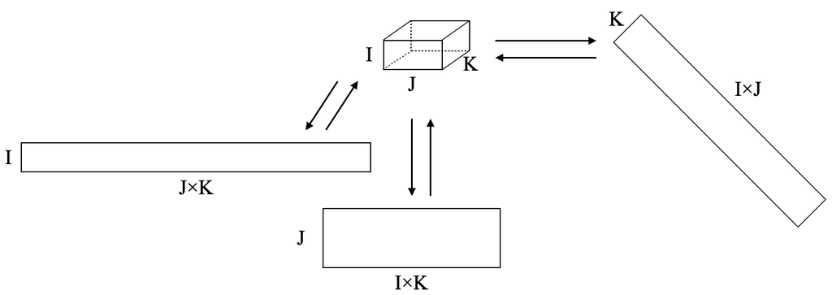

Figure 1: Unfold/Fold Operasions

In `unfold`, `row_idx`/`col_idx` are specified to set which modes are used as the row/column.

```r
dmat1 <- DelayedTensor::unfold(darr1, row_idx=c(1,2), col_idx=3)
dmat1
```

```
## <6 x 4> matrix of class HDF5Matrix and type "double":
##            [,1]       [,2]       [,3]       [,4]
## [1,] 0.36504425 0.69920049 0.01411465 0.13029266
## [2,] 0.98980349 0.80279495 0.63075963 0.77401716
## [3,] 0.31584641 0.93832822 0.92435268 0.40935253
## [4,] 0.84305493 0.03590615 0.69697220 0.89501095
## [5,] 0.66027436 0.15279044 0.99433888 0.48946465
## [6,] 0.53591646 0.97195289 0.04524991 0.49017095
```

`fold` is the inverse operation of `unfold`, which is used to reshape a matrix into a tensor.

In `fold`, `row_idx`/`col_idx` are specified to set which modes correspond the row/column of the output tensor and `modes` is specified to set the mode of the output tensor.

```r
dmat1_to_darr1 <- DelayedTensor::fold(dmat1,
    row_idx=c(1,2), col_idx=3, modes=dim(darr1))
dmat1_to_darr1
```

```
## <2 x 3 x 4> array of class DelayedArray and type "double":
## ,,1
##           [,1]      [,2]      [,3]
## [1,] 0.3650442 0.3158464 0.6602744
## [2,] 0.9898035 0.8430549 0.5359165
##
## ,,2
##            [,1]       [,2]       [,3]
## [1,] 0.69920049 0.93832822 0.15279044
## [2,] 0.80279495 0.03590615 0.97195289
##
## ,,3
##            [,1]       [,2]       [,3]
## [1,] 0.01411465 0.92435268 0.99433888
## [2,] 0.63075963 0.69697220 0.04524991
##
## ,,4
##           [,1]      [,2]      [,3]
## [1,] 0.1302927 0.4093525 0.4894647
## [2,] 0.7740172 0.8950110 0.4901710
```

```r
identical(as.array(darr1), as.array(dmat1_to_darr1))
```

```
## [1] TRUE
```

There are some wrapper fuctions of `unfold` and `fold`.

For example, in `k_unfold`, mode `m` is used as the row and the other modes are is used as the column.

`k_fold` is the inverse operation of `k_unfold`.

```r
dmat2 <- DelayedTensor::k_unfold(darr1, m=1)
dmat2_to_darr1 <- k_fold(dmat2, m=1, modes=dim(darr1))
identical(as.array(darr1), as.array(dmat2_to_darr1))
```

```
## [1] TRUE
```

```r
dmat3 <- DelayedTensor::k_unfold(darr1, m=2)
dmat3_to_darr1 <- k_fold(dmat3, m=2, modes=dim(darr1))
identical(as.array(darr1), as.array(dmat3_to_darr1))
```

```
## [1] TRUE
```

```r
dmat4 <- DelayedTensor::k_unfold(darr1, m=3)
dmat4_to_darr1 <- k_fold(dmat4, m=3, modes=dim(darr1))
identical(as.array(darr1), as.array(dmat4_to_darr1))
```

```
## [1] TRUE
```

In `rs_unfold`, mode `m` is used as the row and the other modes are is used as the column.

`rs_fold` and `rs_unfold` also perform the same operations.

On the other hand, `cs_unfold` specifies the mode `m` as the column and the other modes are specified as the column.

`cs_fold` is the inverse operation of `cs_unfold`.

```r
dmat8 <- DelayedTensor::cs_unfold(darr1, m=1)
dmat8_to_darr1 <- DelayedTensor::cs_fold(dmat8, m=1, modes=dim(darr1))
identical(as.array(darr1), as.array(dmat8_to_darr1))
```

```
## [1] TRUE
```

```r
dmat9 <- DelayedTensor::cs_unfold(darr1, m=2)
dmat9_to_darr1 <- DelayedTensor::cs_fold(dmat9, m=2, modes=dim(darr1))
identical(as.array(darr1), as.array(dmat9_to_darr1))
```

```
## [1] TRUE
```

```r
dmat10 <- DelayedTensor::cs_unfold(darr1, m=3)
dmat10_to_darr1 <- DelayedTensor::cs_fold(dmat10, m=3, modes=dim(darr1))
identical(as.array(darr1), as.array(dmat10_to_darr1))
```

```
## [1] TRUE
```

In `matvec`, m=2 is specified as unfold.

`unmatvec` is the inverse operation of `matvec`.

```r
dmat11 <- DelayedTensor::matvec(darr1)
dmat11_darr1 <- DelayedTensor::unmatvec(dmat11, modes=dim(darr1))
identical(as.array(darr1), as.array(dmat11_darr1))
```

```
## [1] TRUE
```

`ttm` multiplies a tensor by a matrix.

`m` specifies in which mode the matrix will be multiplied.

```r
dmatZ <- RandomUnifArray(c(10,4))
DelayedTensor::ttm(darr1, dmatZ, m=3)
```

```
## <2 x 3 x 10> array of class DelayedArray and type "double":
## ,,1
##           [,1]      [,2]      [,3]
## [1,] 0.1980300 0.3295796 0.5010265
## [2,] 0.6556814 0.6030558 0.3338401
##
## ,,2
##           [,1]      [,2]      [,3]
## [1,] 0.5714507 1.2840710 0.9624248
## [2,] 1.4245203 1.0452414 1.0024064
##
## ,,3
##           [,1]      [,2]      [,3]
## [1,] 0.8649215 1.1220010 0.6607319
## [2,] 1.4892314 0.7549565 1.2890633
##
## ...
##
## ,,8
##           [,1]      [,2]      [,3]
## [1,] 0.3064947 0.7011058 0.8418956
## [2,] 1.0084971 0.8892879 0.5070847
##
## ,,9
##           [,1]      [,2]      [,3]
## [1,] 0.5860211 1.2956308 0.9927789
## [2,] 1.4051197 0.9836275 0.9588006
##
## ,,10
##           [,1]      [,2]      [,3]
## [1,] 0.3124020 0.8066954 1.0559087
## [2,] 1.3607696 1.3927874 0.7143748
```

`ttl` multiplies a tensor by multiple matrices.

`ms` specifies in which mode these matrices will be multiplied.

```r
dmatX <- RandomUnifArray(c(10,2))
dmatY <- RandomUnifArray(c(10,3))
dlizt <- list(dmatX = dmatX, dmatY = dmatY)
DelayedTensor::ttl(darr1, dlizt, ms=c(1,2))
```

```
## <10 x 10 x 4> array of class DelayedArray and type "double":
## ,,1
##            [,1]      [,2]      [,3] ...      [,9]     [,10]
##  [1,] 1.6240276 1.5210639 1.3205737   . 0.9087246 1.2034085
##  [2,] 1.2445184 1.2464851 0.9741999   . 0.5524230 0.8450481
##   ...         .         .         .   .         .         .
##  [9,] 1.6080049 1.5087000 1.3063102   . 0.8950546 1.1890144
## [10,] 0.4241345 0.3639708 0.3604270   . 0.2965512 0.3460250
##
## ...
##
## ,,4
##            [,1]      [,2]      [,3] ...      [,9]     [,10]
##  [1,]  1.264844  1.244641  1.085729   . 0.7758861 1.1050812
##  [2,]  1.070348  1.099901  0.868547   . 0.5151901 0.8155774
##   ...         .         .         .   .         .         .
##  [9,] 1.2556688 1.2371367 1.0762115   . 0.7656367 1.0931566
## [10,] 0.2887413 0.2649355 0.2685191   . 0.2352943 0.3014689
```

## 2.2 Vectorization

`vec` collapses a *DelayedArray* into a 1D *DelayedArray* (vector).

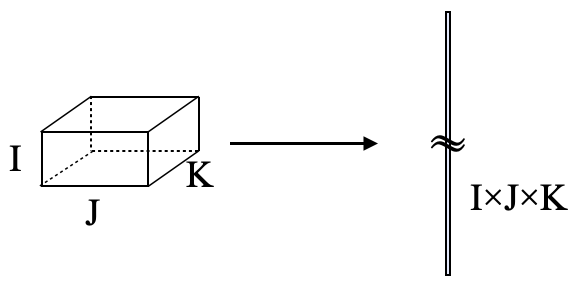

Figure 2: Vectorization

```r
DelayedTensor::vec(darr1)
```

```
## <24> array of class HDF5Array and type "double":
##       [1]       [2]       [3]         .      [23]      [24]
## 0.3650442 0.9898035 0.3158464         . 0.4894647 0.4901710
```

## 2.3 Norm Operations

`fnorm` calculates the Frobenius norm of a *DelayedArray*.

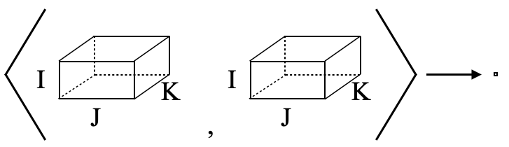

Figure 3: Norm Operations

```r
DelayedTensor::fnorm(darr1)
```

```
## [1] 3.228519
```

`innerProd` calculates the inner product value of two *DelayedArray*.

```r
DelayedTensor::innerProd(darr1, darr2)
```

```
## [1] 6.976722
```

## 2.4 Outer Product

Inner product multiplies two tensors and collapsed to 0D tensor (norm). On the hand, outer product is an operation that leaves all subscripts intact.

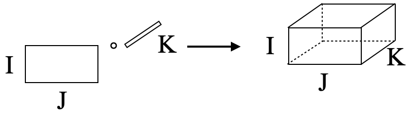

Figure 4: Outer Product

```r
DelayedTensor::outerProd(darr1[,,1], darr2[,,1])
```

```
## <2 x 3 x 2 x 3> array of class HDF5Array and type "double":
## ,,1,1
##           [,1]      [,2]      [,3]
## [1,] 0.3179668 0.2751137 0.5751229
## [2,] 0.8621547 0.7343314 0.4668027
##
## ,,2,1
##           [,1]      [,2]      [,3]
## [1,] 0.2697098 0.2333604 0.4878381
## [2,] 0.7313079 0.6228840 0.3959573
##
## ,,1,2
##            [,1]       [,2]       [,3]
## [1,] 0.02863668 0.02477725 0.05179665
## [2,] 0.07764727 0.06613526 0.04204112
##
## ,,2,2
##           [,1]      [,2]      [,3]
## [1,] 0.3230778 0.2795359 0.5843675
## [2,] 0.8760131 0.7461351 0.4743061
##
## ,,1,3
##           [,1]      [,2]      [,3]
## [1,] 0.3069089 0.2655461 0.5551219
## [2,] 0.8321716 0.7087936 0.4505687
##
## ,,2,3
##           [,1]      [,2]      [,3]
## [1,] 0.1880119 0.1626731 0.3400668
## [2,] 0.5097870 0.4342059 0.2760177
```

## 2.5 Diagonal Operations

Using `DelayedDiagonalArray`, we can originally create a diagonal *DelayedArray* by specifying the dimensions (modes) and the values.

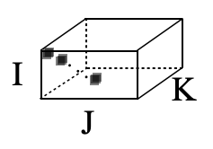

Figure 5: Diagonal Operations

```r
dgdarr <- DelayedTensor::DelayedDiagonalArray(c(5,6,7), 1:5)
dgdarr
```

```
## <5 x 6 x 7> sparse array of class DelayedArray and type "integer":
## ,,1
##      [,1] [,2] [,3] [,4] [,5] [,6]
## [1,]    1    0    0    0    0    0
## [2,]    0    0    0    0    0    0
## [3,]    0    0    0    0    0    0
## [4,]    0    0    0    0    0    0
## [5,]    0    0    0    0    0    0
##
## ...
##
## ,,7
##      [,1] [,2] [,3] [,4] [,5] [,6]
## [1,]    0    0    0    0    0    0
## [2,]    0    0    0    0    0    0
## [3,]    0    0    0    0    0    0
## [4,]    0    0    0    0    0    0
## [5,]    0    0    0    0    0    0
```

Similar to the `diag` of the *base* package, the `diag` of *DelayedTensor* is used to extract and assign values to *DelayedArray*.

```r
DelayedTensor::diag(dgdarr)
```

```
## <5> array of class DelayedArray and type "integer":
## [1] [2] [3] [4] [5]
##   1   2   3   4   5
```

```r
DelayedTensor::diag(dgdarr) <- c(1111, 2222, 3333, 4444, 5555)
DelayedTensor::diag(dgdarr)
```

```
## <5> array of class DelayedArray and type "double":
##  [1]  [2]  [3]  [4]  [5]
## 1111 2222 3333 4444 5555
```

## 2.6 Mode-wise Operations

`modeSum` calculates the summation for a given mode `m` of a *DelayedArray*. The mode specified as `m` is collapsed into 1D as follows.

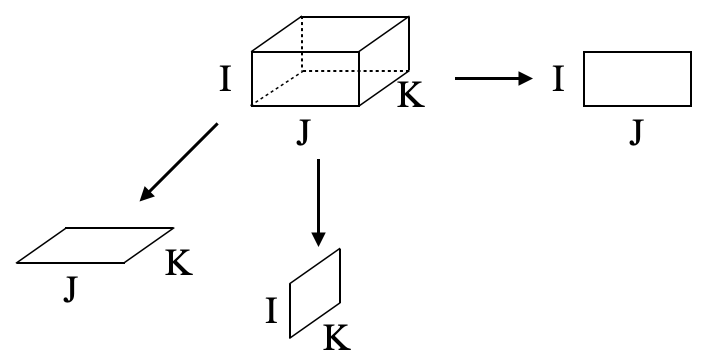

Figure 6: Mode-wise Operations

```r
DelayedTensor::modeSum(darr1, m=1)
```

```
## <1 x 3 x 4> array of class DelayedArray and type "double":
## ,,1
##          [,1]     [,2]     [,3]
## [1,] 1.354848 1.158901 1.196191
##
## ,,2
##           [,1]      [,2]      [,3]
## [1,] 1.5019954 0.9742344 1.1247433
##
## ,,3
##           [,1]      [,2]      [,3]
## [1,] 0.6448743 1.6213249 1.0395888
##
## ,,4
##           [,1]      [,2]      [,3]
## [1,] 0.9043098 1.3043635 0.9796356
```

```r
DelayedTensor::modeSum(darr1, m=2)
```

```
## <2 x 1 x 4> array of class DelayedArray and type "double":
## ,,1
##          [,1]
## [1,] 1.341165
## [2,] 2.368775
##
## ,,2
##          [,1]
## [1,] 1.790319
## [2,] 1.810654
##
## ,,3
##          [,1]
## [1,] 1.932806
## [2,] 1.372982
##
## ,,4
##          [,1]
## [1,] 1.029110
## [2,] 2.159199
```

```r
DelayedTensor::modeSum(darr1, m=3)
```

```
## <2 x 3 x 1> array of class DelayedArray and type "double":
## ,,1
##          [,1]     [,2]     [,3]
## [1,] 1.208652 2.587880 2.296868
## [2,] 3.197375 2.470944 2.043290
```

Similar to `modeSum`, `modeMean` calculates the average value for a given mode `m` of a *DelayedArray*.

```r
DelayedTensor::modeMean(darr1, m=1)
```

```
## <1 x 3 x 4> array of class DelayedArray and type "double":
## ,,1
##           [,1]      [,2]      [,3]
## [1,] 0.6774239 0.5794507 0.5980954
##
## ,,2
##           [,1]      [,2]      [,3]
## [1,] 0.7509977 0.4871172 0.5623717
##
## ,,3
##           [,1]      [,2]      [,3]
## [1,] 0.3224371 0.8106624 0.5197944
##
## ,,4
##           [,1]      [,2]      [,3]
## [1,] 0.4521549 0.6521817 0.4898178
```

```r
DelayedTensor::modeMean(darr1, m=2)
```

```
## <2 x 1 x 4> array of class DelayedArray and type "double":
## ,,1
##           [,1]
## [1,] 0.4470550
## [2,] 0.7895916
##
## ,,2
##           [,1]
## [1,] 0.5967730
## [2,] 0.6035513
##
## ,,3
##           [,1]
## [1,] 0.6442687
## [2,] 0.4576606
##
## ,,4
##           [,1]
## [1,] 0.3430366
## [2,] 0.7197330
```

```r
DelayedTensor::modeMean(darr1, m=3)
```

```
## <2 x 3 x 1> array of class DelayedArray and type "double":
## ,,1
##           [,1]      [,2]      [,3]
## [1,] 0.3021630 0.6469700 0.5742171
## [2,] 0.7993438 0.6177361 0.5108226
```

## 2.7 Tensor Product Operations

There are some tensor specific product such as Hadamard product, Kronecker product, and Khatri-Rao product.

### 2.7.1 Hadamard Product

Suppose a tensor $A \in \Re ^{I \times J}$ and a tensor $B \in \Re ^{I \times J}$.

Hadamard product is defined as the element-wise product of $A$ and $B$.

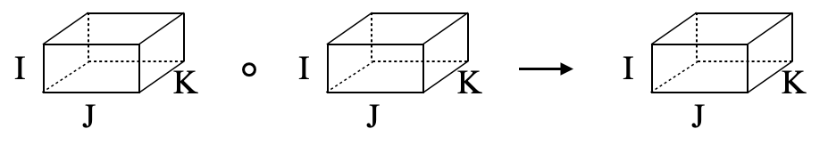

Figure 7: Hadamard Product

Hadamard product can be extended to higher-order tensors.

$$A \circ B = \begin{bmatrix}
a_{11}b_{11} & a_{12}b_{12} & \cdots & a_{1J}b_{1J} \\
a_{21}b_{21} & a_{22}b_{22} & \cdots & a_{2J}b_{2J} \\
\vdots & \vdots & \ddots & \vdots \\
a_{I1}b_{I1} & a_{I2}b_{I2} & \cdots & a_{IJ}b_{IJ} \\
\end{bmatrix}$$

`hadamard` calculates Hadamard product of two *DelayedArray* objects.

```r
prod_h <- DelayedTensor::hadamard(darr1, darr2)
dim(prod_h)
```

```
## [1] 2 3 4
```

`hadamard_list` calculates Hadamard product of multiple *DelayedArray* objects.

```r
prod_hl <- DelayedTensor::hadamard_list(list(darr1, darr2))
dim(prod_hl)
```

```
## [1] 2 3 4
```

### 2.7.2 Kronecker Product

Suppose a tensor $A \in \Re ^{I \times J}$ and a tensor $B \in \Re ^{K \times L}$.

Kronecker product is defined as all the possible combination of element-wise product and the dimensions of output tensor is ${IK \times JL}$.

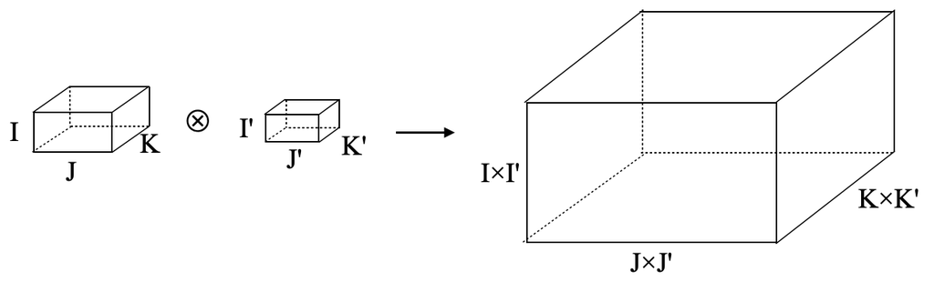

Figure 8: Kronecker Product

Kronecker product can be extended to higher-order tensors.

$$A \otimes B = \begin{bmatrix}
a_{11}B & a_{12}B & \cdots & a_{1J}B \\
a_{21}B & a_{22}B & \cdots & a_{2J}B \\
\vdots & \vdots & \ddots & \vdots \\
a_{I1}B & a_{I2}B & \cdots & a_{IJ}B \\
\end{bmatrix}$$

`kronecker` calculates Kronecker product of two *DelayedArray* objects.

```r
prod_kron <- DelayedTensor::kronecker(darr1, darr2)
dim(prod_kron)
```

```
## [1]  4  9 16
```

`kronecker_list` calculates Kronecker product of multiple *DelayedArray* objects.

```r
prod_kronl <- DelayedTensor::kronecker_list(list(darr1, darr2))
dim(prod_kronl)
```

```
## [1]  4  9 16
```

### 2.7.3 Khatri-Rao Product

Suppose a tensor $A \in \Re ^{I \times J}$ and a tensor $B \in \Re ^{K \times J}$.

Khatri-Rao product is defined as the column-wise Kronecker product and the dimensions of output tensor is ${IK \times J}$.

$$A \odot B = \begin{bmatrix}
a_{1} \otimes a_{1} & a_{2} \otimes a_{2} & \cdots & a_{J} \otimes a_{J} \\
\end{bmatrix}$$

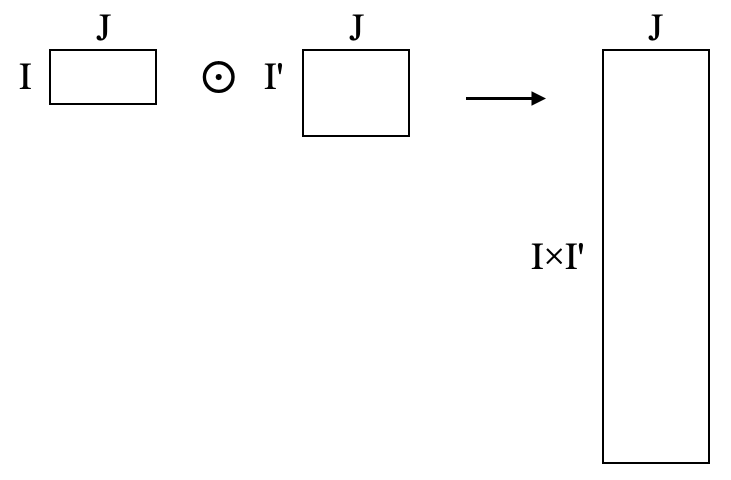

Figure 9: Khatri-Rao Product

Khatri-Rao product can only be used for 2D tensors (matrices).

`khatri_rao` calculates Khatri-Rao product of two *DelayedArray* objects.

```r
prod_kr <- DelayedTensor::khatri_rao(darr1[,,1], darr2[,,1])
dim(prod_kr)
```

```
## [1] 4 3
```

`khatri_rao_list` calculates Khatri-Rao product of multiple *DelayedArray* objects.

```r
prod_krl <- DelayedTensor::khatri_rao_list(list(darr1[,,1], darr2[,,1]))
dim(prod_krl)
```

```
## [1] 4 3
```

## 2.8 Utilities Functions

`list_rep` replicates an arbitrary number of any R object.

```r
str(DelayedTensor::list_rep(darr1, 3))
```

```
## List of 3
##  $ :Formal class 'RandomUnifArray' [package "DelayedRandomArray"] with 1 slot
##   .. ..@ seed:Formal class 'RandomUnifArraySeed' [package "DelayedRandomArray"] with 6 slots
##   .. .. .. ..@ min     : num 0
##   .. .. .. ..@ max     : num 1
##   .. .. .. ..@ dim     : int [1:3] 2 3 4
##   .. .. .. ..@ chunkdim: int [1:3] 2 3 4
##   .. .. .. ..@ seeds   :List of 1
##   .. .. .. .. ..$ : int [1:2] -2106807145 996747319
##   .. .. .. ..@ sparse  : logi FALSE
##  $ :Formal class 'RandomUnifArray' [package "DelayedRandomArray"] with 1 slot
##   .. ..@ seed:Formal class 'RandomUnifArraySeed' [package "DelayedRandomArray"] with 6 slots
##   .. .. .. ..@ min     : num 0
##   .. .. .. ..@ max     : num 1
##   .. .. .. ..@ dim     : int [1:3] 2 3 4
##   .. .. .. ..@ chunkdim: int [1:3] 2 3 4
##   .. .. .. ..@ seeds   :List of 1
##   .. .. .. .. ..$ : int [1:2] -2106807145 996747319
##   .. .. .. ..@ sparse  : logi FALSE
##  $ :Formal class 'RandomUnifArray' [package "DelayedRandomArray"] with 1 slot
##   .. ..@ seed:Formal class 'RandomUnifArraySeed' [package "DelayedRandomArray"] with 6 slots
##   .. .. .. ..@ min     : num 0
##   .. .. .. ..@ max     : num 1
##   .. .. .. ..@ dim     : int [1:3] 2 3 4
##   .. .. .. ..@ chunkdim: int [1:3] 2 3 4
##   .. .. .. ..@ seeds   :List of 1
##   .. .. .. .. ..$ : int [1:2] -2106807145 996747319
##   .. .. .. ..@ sparse  : logi FALSE
```

### 2.8.1 Bind Operations

`modebind_list` collapses multiple *DelayedArray* objects into single *DelayedArray* object.

`m` specifies the collapsed dimension.

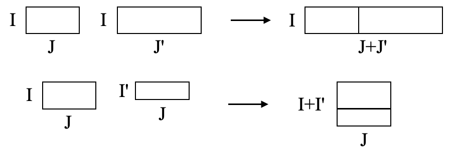

Figure 10: Bind Operations

```r
dim(DelayedTensor::modebind_list(list(darr1, darr2), m=1))
```

```
## [1] 4 3 4
```

```r
dim(DelayedTensor::modebind_list(list(darr1, darr2), m=2))
```

```
## [1] 2 6 4
```

```r
dim(DelayedTensor::modebind_list(list(darr1, darr2), m=3))
```

```
## [1] 2 3 8
```

`rbind_list` is the row-wise `modebind_list` and collapses multiple 2D *DelayedArray* objects into single *DelayedArray* object.

```r
dim(DelayedTensor::rbind_list(list(darr1[,,1], darr2[,,1])))
```

```
## [1] 4 3
```

`cbind_list` is the column-wise `modebind_list` and collapses multiple 2D *DelayedArray* objects into single *DelayedArray* object.

```r
dim(DelayedTensor::cbind_list(list(darr1[,,1], darr2[,,1])))
```

```
## [1] 2 6
```